# INGESTA DE ALCOHOL: ANÁLISIS DE SU RELACIÓN CON EL ESTATUS DE LOS PAÍSES COMO EQUIVALENTE DE COMPETITIVIDAD

Danmara Dos Ramos y Rosmary García

`19/10/2025

```r
library(readr)
Life_Expectancy_Data_2_csv <- read_csv2("./Life Expectancy Data.csv")
```

```
## ℹ Using "','" as decimal and "'.'" as grouping mark. Use `read_delim()` for more control.
```

```r
View(Life_Expectancy_Data_2_csv)
```

[figure not shown]

Entonces, en el contexto de la competitividad podemos equiparar a esta la distinticion entre paises desarrollados y en vías de desarrollo y así, conforme a los datos disponibles sobre expectativas de vida de Estados miembros de distintos esquemas de integracion economica, donde figuran, entre otros países por América: la Comunidad Andina de Naciones (CAN)con Bolivia, Colombia, Ecuador y Perú; el Mercado Común del Sur (Mercosur) con Argentina, Brasil, Paraguay y Uruguay; Estados Unidos y Canadá con un tratado multilateral conocido como T-MEC y por Europa, la Unión Europea (EU)con Alemania, Austria, Bélgica, Bulgaria, Chipre, Croacia, Dinamarca, Eslovaquia, Eslovenia, España, Estonia, Finlandia, Francia, Grecia, Hungría, Irlanda, Italia, Letonia, Lituania, Luxemburgo, Malta, Países Bajos, Polonia, Portugal, República Checa, Rumanía y Suecia. Cada unos de ellos en relación a Venezuela como ex miembro de la CAN, país suspendido indefinidamente de MERCOSUR y Estado Sancionado por medidas unilaterales y coercitivas por la mayoría de los países miembros de la Union Europea (UE):Xy de la T-MEC, estudiar las variables de status, expectativa de vida, mortalidad adultos, muertes infantiles y escolarización condicionadas por la ingesta de alcohol, a fin de conocer si el consumo de tal droga lícita afectó o no el status de países desarrollados o en vías de desarrollo, para el año 2015.

[figure not shown]

¿Cómo es el consumo de alcohol y la competitividad en países desarrollados y en vías de desarrollo en 2015, medida por las variables expectativa de vida, mortalidad de adultos, muerte de infantes y escolarización?

# OBJETIVOS ESPECÍFICOS

1. Comparar el status de los países según el consumo de alcohol por su relación con las variables de expectativa de vida, mortalidad de adultos, muerte de infantes y escolarización.
2. Establecer la relación estadística entre el consumo de alcohol y cada variable, por separado, dentro de cada región (CAN, MERCOSUR, T-MEC y Unión Europea).
3. Realizar un análisis comparativo del estatus de cada región en 2015, en función de cómo el consumo de alcohol se asocia a cada variable, para identificar patrones y diferencias.

```r
library(dplyr)
library(ggplot2)

# Filtrar SOLO para el año 2015
datos_2015 <- Life_Expectancy_Data_2_csv %>%
  filter(Year == 2015) %>%

  # Seleccionar solo las columnas necesarias para el análisis de la Pregunta 1
  select(Country, Year, Status, `Alcohol`,
         `Life Expectancy`, `Adult Mortality`,
         `Infant Deaths`, `Schooling`)

# Crea un dataframe ESPECIALMENTE para la Prueba T de ALCOHOL
# Aquí filtramos las NAs para las variables EXACTAS que compararemos.
datos_t_test_alcohol <- datos_2015 %>%
  filter(!is.na(`Alcohol`), !is.na(Status))

# Imprimimos el conteo para ver si hay suficientes datos en cada grupo
conteo_alcohol <- datos_t_test_alcohol %>%
  group_by(Status) %>%
  summarise(N = n())

print("Conteo de observaciones válidas para la Prueba T (Alcohol):")
```

```
## [1] "Conteo de observaciones válidas para la Prueba T (Alcohol):"
```

```r
print(conteo_alcohol)
```

```
## # A tibble: 2 × 2
##   Status         N
##   <chr>      <int>
## 1 Developed      4
## 2 Developing     2
```

```r
# Cálculo de estadísticas descriptivas agrupadas por 'Status'
comparacion_descriptiva <- datos_2015 %>%
  group_by(Status) %>%
  summarise(
    N = n(),

    # Medias y SDs para las variables clave
    Alcohol_Media = mean(`Alcohol`, na.rm = TRUE),
    Vida_Media = mean(`Life Expectancy`, na.rm = TRUE),
    Mortalidad_Adultos_Media = mean(`Adult Mortality`, na.rm = TRUE),
    Muertes_Infantes_Media = mean(`Infant Deaths`, na.rm = TRUE),
    Escolarizacion_Media = mean(`Schooling`, na.rm = TRUE)
  )
# Mostrar la tabla
print(comparacion_descriptiva)
```

```
## # A tibble: 2 × 7
##   Status         N Alcohol_Media Vida_Media Mortalidad_Adultos_Media
##   <chr>      <int>         <dbl>      <dbl>                    <dbl>
## 1 Developed     32            NA       645.                     74.9
## 2 Developing   151            NA       604.                    169.
## # ℹ 2 more variables: Muertes_Infantes_Media <dbl>, Escolarizacion_Media <dbl>
```

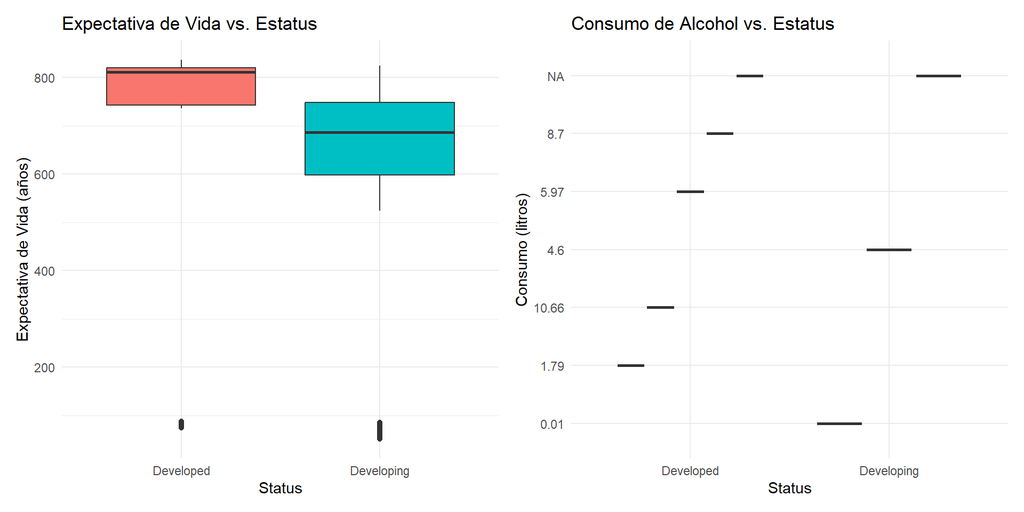

```r
# Para mostrar múltiples gráficas en una fila
library(patchwork)

# Gráfica de Expectativa de Vida
p1 <- ggplot(datos_2015, aes(x = Status, y = `Life Expectancy`, fill = Status)) +
  geom_boxplot() +
  labs(title = "Expectativa de Vida vs. Estatus", y = "Expectativa de Vida (años)") +
  theme_minimal() + theme(legend.position = "none")

# Gráfica de Consumo de Alcohol
p2 <- ggplot(datos_2015, aes(x = Status, y = `Alcohol`, fill = Status)) +
  geom_boxplot() +
  labs(title = "Consumo de Alcohol vs. Estatus", y = "Consumo (litros)") +
  theme_minimal() + theme(legend.position = "none")

# Combina las dos gráficas
p1 + p2
```